# Trabalho_Extração, Grupo8

## 6.2 Clustering

O processo de *clustering* realiza o agrupamento de variáveis pela sua similaridade, podendo ser este hierático ou por um problema de otimização de k-means, a qual lhe é dado como parâmetro inicial o número de *clusters* avaliando a melhor posição para o centroide de cada cluster. Idealmente pretende-se obter a menor distancia entre o cluster e os pontos a que estes pertencem.

O processo de *clustering* foi realizado para o top 50 dos genes com valor de p mais reduzido segundo a distancia *euclidean*.

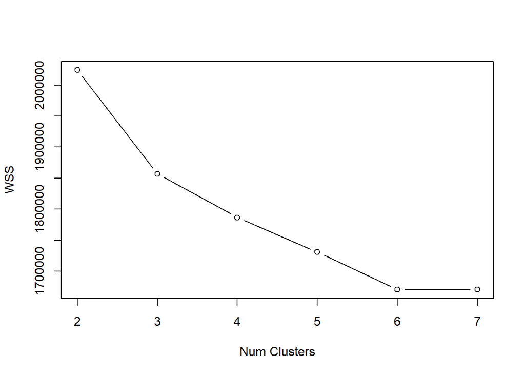

```r
#Expression

wss = c()
for (k in 2:7) wss = c(wss, sum(kmeans(Sub_CCLE_expression_UP, centers=k)$withinss) )
plot(2:7, wss, type="b", xlab="Num Clusters", ylab="WSS")
```

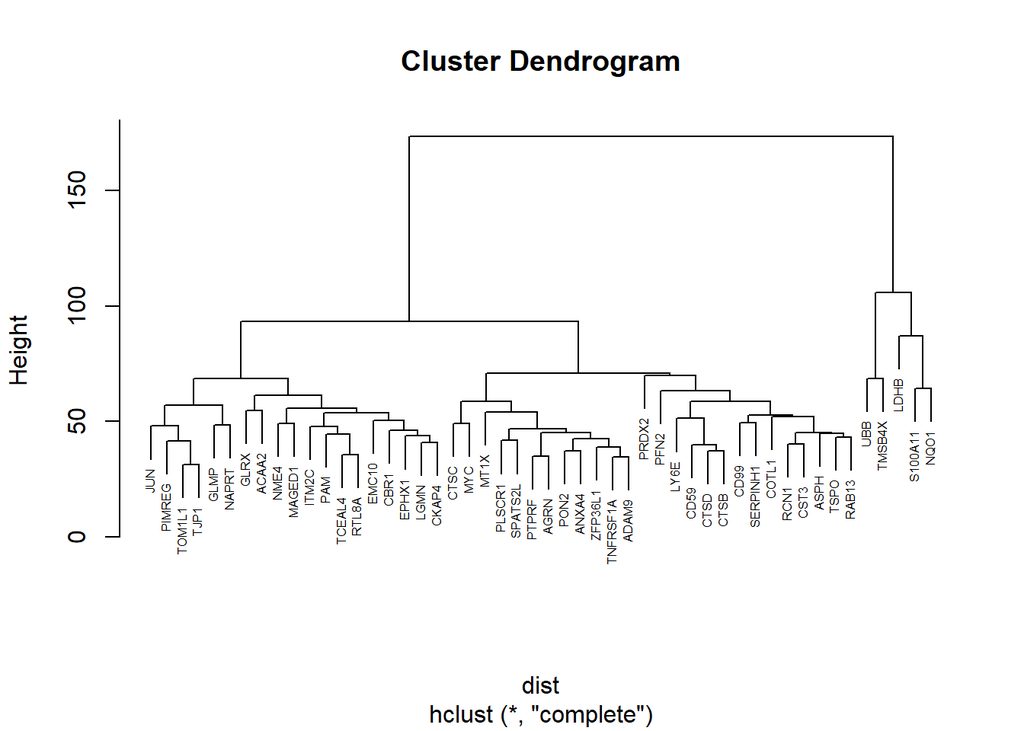

```r
#Clustering Hierarquico para o top 50 de genes
inv = t(Sub_CCLE_expression_UP)
rownames(inv) <- make.names(rownames(inv), unique = TRUE)
tt = rowttests(inv)
rank = order(tt$p.value)
p50 = rank[1:50]
Best50 = inv[p50,]
order_cols = order(Sample_Info$primary_disease)
Best50 = Best50[,order_cols]
dist = dist(Best50, method = 'euclidean')
clust.gene = hclust(dist)
plot(clust.gene, cex = 0.5)
```

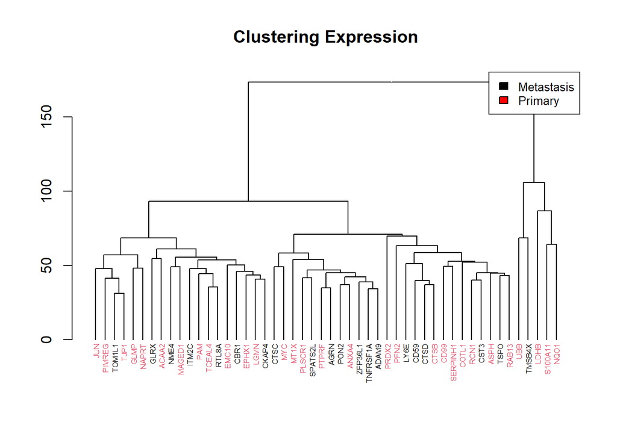

```r
dend <- as.dendrogram(clust.gene, cex= 0.5)
colors_to_use <- as.numeric(as.factor(Sample_Info$primary_or_metastasis))
colors_to_use <- colors_to_use[order.dendrogram(dend)]
labels_colors(dend) <- colors_to_use
dend <- dend %>%set("labels_cex", 0.5)
plot(dend, main = "Clustering Expression", cex = 0.5)
legend("topright", legend = levels(as.factor(Sample_Info$primary_or_metastasis)), cex = 0.8, fill = c("black","red"))
```

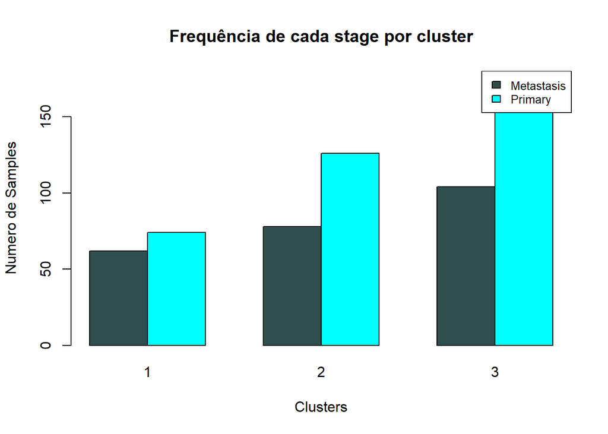

```r
#K-means tendo em conta o o estado do cancro
kmeans.exp = kmeans(Sub_CCLE_expression_UP, centers = 3, nstart = 1000)
means_type = table(kmeans.exp$cluster, Sample_Info$primary_or_metastasis)
barplot(t(means_type), beside=T, col=c("darkslategrey","cyan"), xlab="Clusters", main="Frequência de cada stage por cluster", ylab="Numero de Samples", ylim = c(0,180) )
legend("topright",legend = levels(as.factor(Sample_Info$primary_or_metastasis)), cex = 0.8 , fill = c("darkslategrey","cyan"))
```

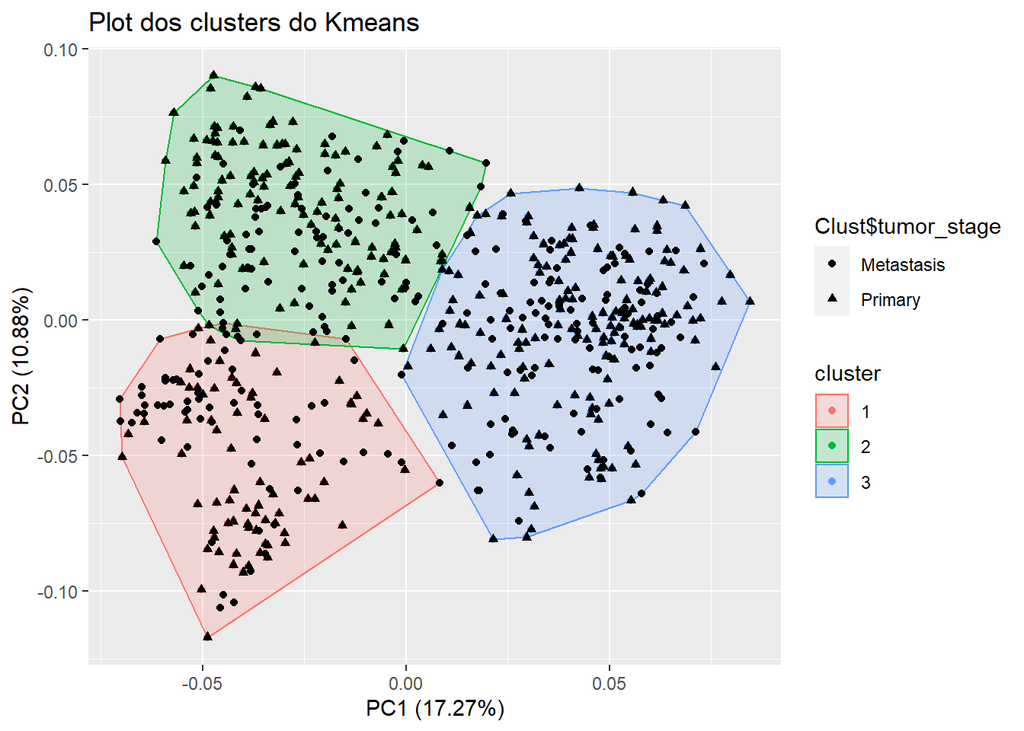

```r
Clust<-as.data.frame(Sub_CCLE_expression_UP)
indx <- sapply(Clust, is.factor)
Clust[indx] <- lapply(Clust[indx], function(x) as.numeric(as.character(x)))
Clust=cbind(Clust,Sample_Info$primary_or_metastasis)
names(Clust)[ncol(Clust)] <- 'tumor_stage'
library(ggfortify)
par(mfrow=c(2,2))
k=autoplot(kmeans.exp, data = (Clust), frame = T, main="Plot dos clusters do Kmeans", legendLabs=NULL)
k+ggplot2::geom_point(aes(pch=Clust$tumor_stage))
```

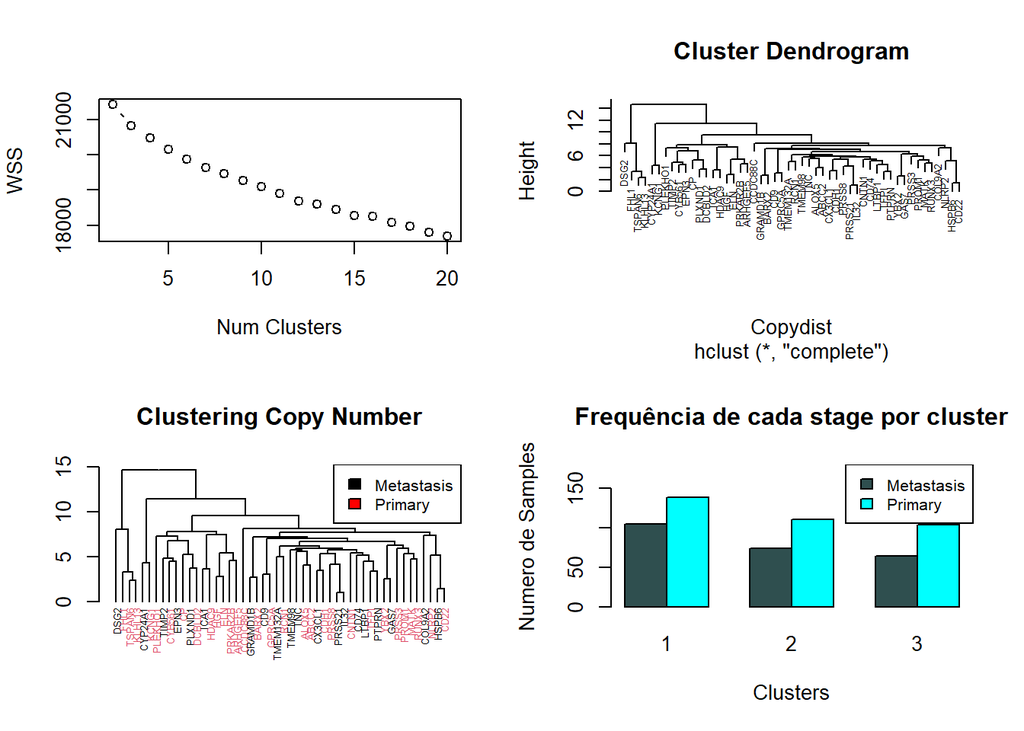

```r
#CopyNumber
wss = c()
for (k in 2:20) wss = c(wss, sum(kmeans(CopyNumber_UP, centers=k)$withinss) )
plot(2:20, wss, type="b", xlab="Num Clusters", ylab="WSS")

#Clustering Hierarquico para o top 50 de genes
inv = t(CopyNumber_UP)
rownames(inv) <- make.names(rownames(inv), unique = TRUE)
Copytt = rowttests(inv)
Copyrank = order(Copytt$p.value)
Copyp50 = Copyrank[1:50]
CopyBest50 = inv[Copyp50,]
Copyorder_cols = order(Sample_Info$primary_disease)
CopyBest50 = CopyBest50[,Copyorder_cols]
Copydist = dist(CopyBest50, method = 'euclidean')
Copyclust.gene = hclust(Copydist)
plot(Copyclust.gene, cex = 0.5)
dendCopy <- as.dendrogram(Copyclust.gene, cex= 0.5)
colors_to_useCopy <- as.numeric(as.factor(Sample_Info$primary_or_metastasis))
colors_to_useCopy <- colors_to_useCopy[order.dendrogram(dendCopy)]
labels_colors(dendCopy) <- colors_to_useCopy
dendCopy <- dendCopy %>%set("labels_cex", 0.5)
plot(dendCopy, main = "Clustering Copy Number", cex = 0.5)
legend("topright", legend = levels(as.factor(Sample_Info$primary_or_metastasis)), cex = 0.8, fill = c("black","red"))


#K-means tendo em conta o o estado do cancro
Copykmeans.exp = kmeans(CopyNumber_UP, centers = 3, nstart = 1000)
Copymeans_type = table(Copykmeans.exp$cluster, Sample_Info$primary_or_metastasis)
barplot(t(Copymeans_type), beside=T, col=c("darkslategrey","cyan"), xlab="Clusters", main="Frequência de cada stage por cluster", ylab="Numero de Samples", ylim = c(0,180) )
legend("topright",legend = levels(as.factor(Sample_Info$primary_or_metastasis)), cex = 0.8 , fill = c("darkslategrey","cyan"))
```

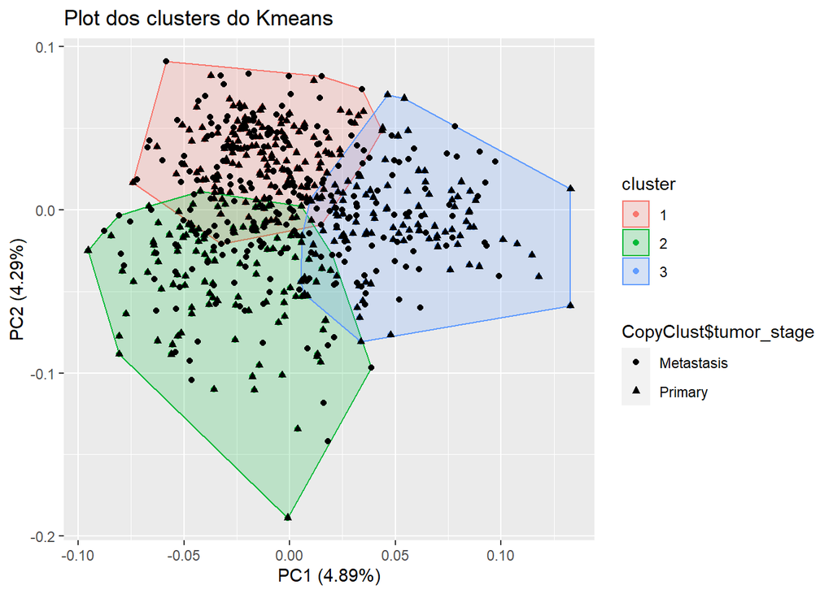

```r
CopyClust<-as.data.frame(CopyNumber_UP)
Copyindx <- sapply(CopyClust, is.factor)
CopyClust[Copyindx] <- lapply(Clust[Copyindx], function(x) as.numeric(as.character(x)))
CopyClust=cbind(CopyClust,Sample_Info$primary_or_metastasis)
names(CopyClust)[ncol(CopyClust)] <- 'tumor_stage'

par(mfrow=c(2,2))
k=autoplot(Copykmeans.exp, data = (CopyClust), frame = T, main="Plot dos clusters do Kmeans", legendLabs=NULL)
k+ggplot2::geom_point(aes(pch=CopyClust$tumor_stage))
```

Após realizar o *clustering* foi possível verificar que as variáveis não se conseguiam distribuir separamente nos vários *clusters*, não obtendo nenhum dos *clustering* testados as variáveis separados nos dendrogramas. Apesar de ter sido modificado o número de *clusters* finais assim como a medida de distância.